# Classify major localisation

Tom Smith

Cambridge Centre for Proteomics

08 November, 2021

Abstract

Here we classify proteins/peptides according to their marker profiles in the unenriched/unmodified LOPIT, using SVM

```r
library(MSnbase)
library(pRoloc)
library(pRolocExt)
library(camprotR)
library(tidyverse)
marker_colours <- getStockcol()[c(1:5, 7:11)]
```

```r
unmod_prot <- readRDS("../results/unmod_prot.rds")
unmod_pep <- readRDS("../results/unmod_pep.rds")
succ_pep <- readRDS("../results/succ_pep.rds")
```

SVM parameter optimisation. Not run by default to avoid excessive run-time.

```r
times
```

```
$prot
[1] 50

$pep
[1] 30
```

We are using just the unmodified peptides here although we could use the concatenated datasets we create below since all markers for the modified peptides are set to ‘unknown’.

```r
sigma <- 2^(-5:0)
cost <- 2^(-2:4)

# less onerous for quicker check
#times <- 10
#sigma <- 2^(-4:-1)
#cost <- 2^(0:3)

params_unmod_prot <- pRoloc::svmOptimisation(
  unmod_prot,
  fcol="markers",
  times=times$prot,
  cost=cost,
  sigma=sigma)




saveRDS(params_unmod_prot, "../results/svm_params_unmod_prot.Rds")

plot(params_unmod_prot)
levelPlot(params_unmod_prot)
getParams(params_unmod_prot)
```

For the optimisation of peptide-level SVM parameters, we will use the protein-level optimal parameters as a start point and vary 2-fold in either direction. We will also limit to 30 iterations. This is to limit the run-time of the optimisation.

```r
sigma <- 2^(-5:-3)
cost <- 2^(2:4)

params_unmod_pep <- pRoloc::svmOptimisation(
  unmod_pep,
  fcol="markers",
  times=times$pep,
  cost=cost,
  sigma=sigma)

saveRDS(params_unmod_pep, "../results/svm_params_unmod_pep.Rds")
```

Read in previous SVM parameter optimisation

```r
params_unmod_prot <- readRDS("../results/svm_params_unmod_prot.Rds")
params_unmod_pep <- readRDS("../results/svm_params_unmod_pep.Rds")
```

Now let’s inspect the marker set level F1 scores

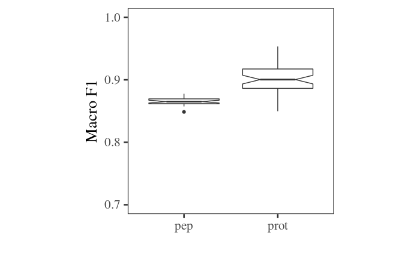

```r
svm_params <- NULL
svm_params$prot <- params_unmod_prot
svm_params$pep <- params_unmod_pep


svm_params %>% names() %>% lapply(function(condition){
    data.frame(getF1Scores(svm_params[[condition]])) %>%
      mutate(condition=condition)
  }) %>% do.call(what='rbind') %>%
      ggplot(aes(condition, F1)) +
    geom_boxplot(notch=TRUE) +
    theme_camprot() +
    ylim(0.7, 1) +
    xlab('') +
    ylab('Macro F1') +
  scale_colour_manual(values=get_cat_palette(3), name='')
```

OK, so very little difference. Protein macro F1 is higher as we might expect but not a huge difference

What about the organelle level F1

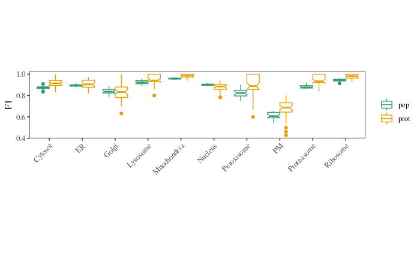

Similar story. In fact, nucleus F1 is sometimes better with peptide!

Combine modified and unmodified peptides so we can use the markers from the unmodified LOPIT and the optimised SVM parameters for these markers to classify all peptides together.

```r
combineLOPITs <- function(lopit1, lopit2){

  tmp_exprs <- rbind(exprs(lopit1), exprs(lopit2))

  tmp_fData1 <- fData(lopit1)
  tmp_fData2 <- fData(lopit2)

  for(col in setdiff(colnames(tmp_fData2), colnames(tmp_fData1))){
    tmp_fData1[[col]] <- NA
  }

  for(col in setdiff(colnames(tmp_fData1), colnames(tmp_fData2))){
    tmp_fData2[[col]] <- NA
  }

  tmp_fData <- rbind(tmp_fData1, tmp_fData2)

  mod_prot_plus_mod_pep <- MSnSet(tmp_exprs, tmp_fData, pData(lopit1))

  invisible(mod_prot_plus_mod_pep)
}

combineUnmodProtModPep <- function(unmod_prot, mod_pep, mod_to_unknown=FALSE){

  combined_data <- combineLOPITs(unmod_prot, mod_pep)
  fData(combined_data)$mod <- c(rep("Unmodified", length(rownames(unmod_prot))),
                                rep("Modified", length(rownames(mod_pep))))

  for(col in fvarLabels(combined_data)[grep("^CV", fvarLabels(combined_data))])

    if(mod_to_unknown){
      # reset the marker column to unknown so that all modified features can be classified
      fData(combined_data)$markers[fData(combined_data)$mod=="Modified"] <- "unknown"
    }

  invisible(combined_data)
}

unmod_pep_succ_pep <- combineUnmodProtModPep(unmod_pep, succ_pep, mod_to_unknown=TRUE)


# Just checking the concatenated dataset is the right dimensions
dim(unmod_pep_succ_pep)
```

```
[1] 77334    10
```

```r
dim(unmod_pep)
```

```
[1] 73793    10
```

```r
dim(succ_pep)
```

```
[1] 3541   10
```

Crude function to filter SVM classifications by a quantile threshold.

```r
addFilteredSVM <- function(obj, quant_thresh=0.75){
  fData(obj)$max.svm <- apply(fData(obj)$svm.all.scores, MARGIN=1, FUN=max)

  obj_no_markers <- obj[fData(obj)$markers=="unknown",]

  svm_individual_threshold <- fData(obj_no_markers) %>%
    group_by(svm) %>%
    summarise(threshold=quantile(max.svm, quant_thresh))

  p <- fData(obj_no_markers) %>%
    data.frame() %>%
    ggplot() +
    geom_boxplot(aes(svm, max.svm)) +
    theme_camprot() +
    theme(axis.text.x=element_text(angle=90, vjust=0.5, hjust=1, size=10))

  print(p)

  print(svm_individual_threshold)
  svm_individual_threshold_list <- svm_individual_threshold$threshold
  names(svm_individual_threshold_list) <- svm_individual_threshold$svm

  fData(obj) <- fData(obj) %>%
    tibble::rownames_to_column() %>%
    rowwise() %>%
    mutate("svm_filtered_ind_thresh"=ifelse(max.svm<svm_individual_threshold_list[[svm]], "unknown", as.character(svm))) %>%
    tibble::column_to_rownames()

  print(table(fData(obj)$svm_filtered_ind_thresh))
  print(fData(obj) %>% filter(markers=="unknown") %>%
          pull(svm_filtered_ind_thresh) %>% table())

  fData(obj)$svm_filtered_single_threshold <- as.character(fData(obj)$svm)
  low_confidence <- apply(fData(obj)$svm.all.scores, MARGIN=1, FUN=max)<0.9
  fData(obj)$svm_filtered_single_threshold[low_confidence] <- "unknown"

  print(table(fData(obj)$svm_filtered_single_threshold))
  print(fData(obj) %>% filter(markers=="unknown") %>%
          pull(svm_filtered_single_threshold) %>% table())

  invisible(obj)
}
```

Classify peptides using SVM

|  | svm | threshold |
| --- | --- | --- |
| 1 | Cytosol | 0.8921687 |
| 2 | ER | 0.8951371 |
| 3 | Golgi | 0.8381822 |
| 4 | Lysosome | 0.9554361 |
| 5 | Mitochondria | 0.9721048 |
| 6 | Nucleus | 0.9164256 |
| 7 | Peroxisome | 0.7912913 |
| 8 | PM | 0.8269946 |
| 9 | Proteasome | 0.8938745 |
| 10 | Ribosome | 0.9486064 |

```
     Cytosol           ER        Golgi     Lysosome Mitochondria      Nucleus   Peroxisome           PM   Proteasome     Ribosome
        5329         3670          774          428         3984         7988          357         1279         1163         2462
     unknown
       49900
.
     Cytosol           ER        Golgi     Lysosome Mitochondria      Nucleus   Peroxisome           PM   Proteasome     Ribosome
        4244         2000          305          131         1519         5644           95          701          588         1411
     unknown
       49900

     Cytosol           ER        Golgi     Lysosome Mitochondria      Nucleus   Peroxisome           PM   Proteasome     Ribosome
        4588         3418          689          575         6959         9460          291          959         1127         3379
     unknown
       45889
.
     Cytosol           ER        Golgi     Lysosome Mitochondria      Nucleus   Peroxisome           PM   Proteasome     Ribosome
        3503         1748          220          278         4494         7116           29          381          552         2328
     unknown
       45889
```

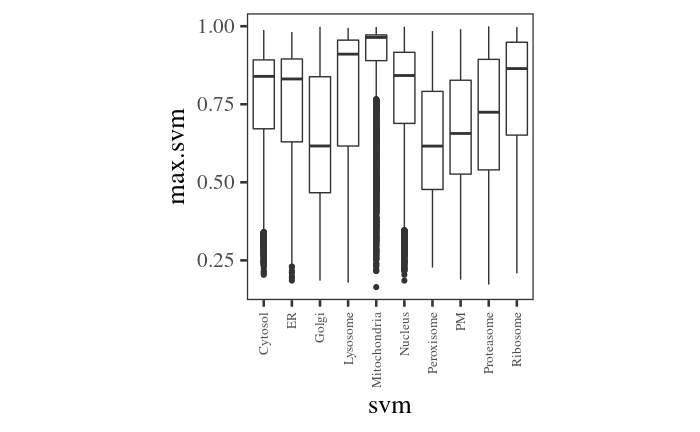

```r
best_params <- getParams(params_unmod_pep)

pep_classifications <- svmClassification(
    unmod_pep_succ_pep, scores="all", cost=best_params[['cost']],
    sigma=best_params[['sigma']], fcol="markers")


pep_classifications <- pep_classifications %>% addFilteredSVM()
```

```r
saveRDS(pep_classifications, '../results/pep_classifications.rds')
```